# Smart Device Trends for Bellabeat

F. Dabrowski

2024-04-13

## Objective

The project’s objective is to analyze smart device usage data to uncover trends, patterns, and provide business recommendations for product development and marketing strategy.

## Tools

Data analysis was conducted using the following tools:

- R: Utilized for date cleaning, analysis and visualization.
- SQL used once in order to merge daily_activity and daily_sleep datasets.

Data integrity was ensured through the following measures:

Methods for data verification included:

- Running integrity checks.
- Reviewing summary statistics.
- Conducting visual inspection of the data.

## Packages

- **tidyverse** - a collection of R packages designed for data science that includes data manipulation, plotting, and more.
- **here** - simplifies the specification of file paths that work across different operating systems.
- **skimr** - provides compact and flexible summaries of data frames.
- **janitor** - tools for cleaning and examining data frames in a simple way.
- **lubridate** - makes it easier to work with dates and times in R.
- **knitr** - allows for dynamic report generation with R, integrating R code into documents.
- **dplyr** - a grammar of data manipulation, providing a consistent set of verbs that help you solve the most common data manipulation challenges.
- **scales** - provides methods for automatically and manually transforming data for visualization purposes.
- **corrplot** - visualizes correlation matrices, typically through a lower triangle plot with colored cells representing different levels of correlation.

## Dataset import: loading and importing data

Datasets uploaded manually, downloaded from Kaggle:

```r
daily_activity <- read_csv(here("bellabeat", "dailyActivity_merged.csv"))
daily_calories <- read_csv(here("bellabeat", "dailyCalories_merged.csv"))
daily_intensities <- read_csv(here("bellabeat", "dailyIntensities_merged.csv"))
daily_sleep <- read_csv(here("bellabeat", "sleepDay_merged.csv"))
daily_steps <- read_csv(here("bellabeat", "dailySteps_merged.csv"))
hourly_calories <- read_csv(here("bellabeat", "hourlyCalories_merged.csv"))
hourly_intensities <- read_csv(here("bellabeat", "hourlyIntensities_merged.csv"))
hourly_steps <- read_csv(here("bellabeat", "hourlySteps_merged.csv"))
weight_log <- read_csv(here("bellabeat", "weightLogInfo_merged.csv"))
```

## Data cleaning

### Participant count verification

```r
n_unique(daily_activity$Id)
```

```
## [1] 33
```

```r
n_unique(daily_sleep$Id)
```

```
## [1] 24
```

```r
n_unique(daily_steps$Id)
```

```
## [1] 33
```

```r
n_unique(hourly_calories$Id)
```

```
## [1] 33
```

```r
n_unique(hourly_intensities$Id)
```

```
## [1] 33
```

```r
n_unique(hourly_steps$Id)
```

```
## [1] 33
```

```r
n_unique(weight_log$Id)
```

```
## [1] 8
```

Removing the weight_log dataset as the sample size of 8 is too small to provide reliable insights during analysis.

```r
rm(weight_log)
```

### Data integrity check: identifying duplicates and missing values

```r
daily_activity <- daily_activity %>%
  distinct() %>%
  drop_na()
daily_calories <- daily_calories %>%
  distinct() %>%
  drop_na()
daily_intensities <- daily_intensities %>%
  distinct() %>%
  drop_na()
daily_sleep <- daily_sleep %>%
  distinct() %>%
  drop_na()
daily_steps <- daily_steps %>%
  distinct() %>%
  drop_na()
hourly_calories <- hourly_calories %>%
  distinct() %>%
  drop_na()
hourly_intensities <- hourly_intensities %>%
  distinct() %>%
  drop_na()
hourly_steps <- hourly_steps %>%
  distinct() %>%
  drop_na()
```

### Standardizing column names

```r
clean_names(daily_activity)
```

```
## # A tibble: 940 × 15
##            id activity_date total_steps total_distance tracker_distance
##         <dbl> <chr>               <dbl>          <dbl>            <dbl>
##  1 1503960366 4/12/2016           13162           8.5              8.5
##  2 1503960366 4/13/2016           10735           6.97             6.97
##  3 1503960366 4/14/2016           10460           6.74             6.74
##  4 1503960366 4/15/2016            9762           6.28             6.28
##  5 1503960366 4/16/2016           12669           8.16             8.16
##  6 1503960366 4/17/2016            9705           6.48             6.48
##  7 1503960366 4/18/2016           13019           8.59             8.59
##  8 1503960366 4/19/2016           15506           9.88             9.88
##  9 1503960366 4/20/2016           10544           6.68             6.68
## 10 1503960366 4/21/2016            9819           6.34             6.34
## # ℹ 930 more rows
## # ℹ 10 more variables: logged_activities_distance <dbl>,
## #   very_active_distance <dbl>, moderately_active_distance <dbl>,
## #   light_active_distance <dbl>, sedentary_active_distance <dbl>,
## #   very_active_minutes <dbl>, fairly_active_minutes <dbl>,
## #   lightly_active_minutes <dbl>, sedentary_minutes <dbl>, calories <dbl>
```

```r
daily_activity <- rename_with(daily_activity, tolower)
clean_names(daily_calories)
```

```
## # A tibble: 940 × 3
##            id activity_day calories
##         <dbl> <chr>           <dbl>
##  1 1503960366 4/12/2016        1985
##  2 1503960366 4/13/2016        1797
##  3 1503960366 4/14/2016        1776
##  4 1503960366 4/15/2016        1745
##  5 1503960366 4/16/2016        1863
##  6 1503960366 4/17/2016        1728
##  7 1503960366 4/18/2016        1921
##  8 1503960366 4/19/2016        2035
##  9 1503960366 4/20/2016        1786
## 10 1503960366 4/21/2016        1775
## # ℹ 930 more rows
```

```r
daily_calories <- rename_with(daily_calories, tolower)
clean_names(daily_intensities)
```

```
## # A tibble: 940 × 10
##            id activity_day sedentary_minutes lightly_active_minutes
##         <dbl> <chr>                    <dbl>                  <dbl>
##  1 1503960366 4/12/2016                  728                    328
##  2 1503960366 4/13/2016                  776                    217
##  3 1503960366 4/14/2016                 1218                    181
##  4 1503960366 4/15/2016                  726                    209
##  5 1503960366 4/16/2016                  773                    221
##  6 1503960366 4/17/2016                  539                    164
##  7 1503960366 4/18/2016                 1149                    233
##  8 1503960366 4/19/2016                  775                    264
##  9 1503960366 4/20/2016                  818                    205
## 10 1503960366 4/21/2016                  838                    211
## # ℹ 930 more rows
## # ℹ 6 more variables: fairly_active_minutes <dbl>, very_active_minutes <dbl>,
## #   sedentary_active_distance <dbl>, light_active_distance <dbl>,
## #   moderately_active_distance <dbl>, very_active_distance <dbl>
```

```r
daily_intensities <- rename_with(daily_intensities, tolower)
clean_names(daily_sleep)
```

```
## # A tibble: 410 × 5
##          id sleep_day total_sleep_records total_minutes_asleep total_time_in_bed
##       <dbl> <chr>                   <dbl>                <dbl>             <dbl>
##  1   1.50e9 4/12/201…                   1                  327               346
##  2   1.50e9 4/13/201…                   2                  384               407
##  3   1.50e9 4/15/201…                   1                  412               442
##  4   1.50e9 4/16/201…                   2                  340               367
##  5   1.50e9 4/17/201…                   1                  700               712
##  6   1.50e9 4/19/201…                   1                  304               320
##  7   1.50e9 4/20/201…                   1                  360               377
##  8   1.50e9 4/21/201…                   1                  325               364
##  9   1.50e9 4/23/201…                   1                  361               384
## 10   1.50e9 4/24/201…                   1                  430               449
## # ℹ 400 more rows
```

```r
daily_sleep <- rename_with(daily_sleep, tolower)
clean_names(daily_steps)
```

```
## # A tibble: 940 × 3
##            id activity_day step_total
##         <dbl> <chr>             <dbl>
##  1 1503960366 4/12/2016         13162
##  2 1503960366 4/13/2016         10735
##  3 1503960366 4/14/2016         10460
##  4 1503960366 4/15/2016          9762
##  5 1503960366 4/16/2016         12669
##  6 1503960366 4/17/2016          9705
##  7 1503960366 4/18/2016         13019
##  8 1503960366 4/19/2016         15506
##  9 1503960366 4/20/2016         10544
## 10 1503960366 4/21/2016          9819
## # ℹ 930 more rows
```

```r
daily_steps <- rename_with(daily_steps, tolower)
clean_names(hourly_calories)
```

```
## # A tibble: 22,099 × 3
##            id activity_hour         calories
##         <dbl> <chr>                    <dbl>
##  1 1503960366 4/12/2016 12:00:00 AM       81
##  2 1503960366 4/12/2016 1:00:00 AM        61
##  3 1503960366 4/12/2016 2:00:00 AM        59
##  4 1503960366 4/12/2016 3:00:00 AM        47
##  5 1503960366 4/12/2016 4:00:00 AM        48
##  6 1503960366 4/12/2016 5:00:00 AM        48
##  7 1503960366 4/12/2016 6:00:00 AM        48
##  8 1503960366 4/12/2016 7:00:00 AM        47
##  9 1503960366 4/12/2016 8:00:00 AM        68
## 10 1503960366 4/12/2016 9:00:00 AM       141
## # ℹ 22,089 more rows
```

```r
hourly_calories <- rename_with(hourly_calories, tolower)
clean_names(hourly_intensities)
```

```
## # A tibble: 22,099 × 4
##            id activity_hour         total_intensity average_intensity
##         <dbl> <chr>                           <dbl>             <dbl>
##  1 1503960366 4/12/2016 12:00:00 AM              20             0.333
##  2 1503960366 4/12/2016 1:00:00 AM                8             0.133
##  3 1503960366 4/12/2016 2:00:00 AM                7             0.117
##  4 1503960366 4/12/2016 3:00:00 AM                0             0
##  5 1503960366 4/12/2016 4:00:00 AM                0             0
##  6 1503960366 4/12/2016 5:00:00 AM                0             0
##  7 1503960366 4/12/2016 6:00:00 AM                0             0
##  8 1503960366 4/12/2016 7:00:00 AM                0             0
##  9 1503960366 4/12/2016 8:00:00 AM               13             0.217
## 10 1503960366 4/12/2016 9:00:00 AM               30             0.5
## # ℹ 22,089 more rows
```

```r
hourly_intensities <- rename_with(hourly_intensities, tolower)
clean_names(hourly_steps)
```

```
## # A tibble: 22,099 × 3
##            id activity_hour         step_total
##         <dbl> <chr>                      <dbl>
##  1 1503960366 4/12/2016 12:00:00 AM        373
##  2 1503960366 4/12/2016 1:00:00 AM         160
##  3 1503960366 4/12/2016 2:00:00 AM         151
##  4 1503960366 4/12/2016 3:00:00 AM           0
##  5 1503960366 4/12/2016 4:00:00 AM           0
##  6 1503960366 4/12/2016 5:00:00 AM           0
##  7 1503960366 4/12/2016 6:00:00 AM           0
##  8 1503960366 4/12/2016 7:00:00 AM           0
##  9 1503960366 4/12/2016 8:00:00 AM         250
## 10 1503960366 4/12/2016 9:00:00 AM        1864
## # ℹ 22,089 more rows
```

```r
hourly_steps <- rename_with(hourly_steps, tolower)
```

### Standardizing dates and time formats

```r
daily_activity <- daily_activity %>%
  rename(date = activitydate) %>%
  mutate(date = as_date(date, format = "%m/%d/%Y"))
daily_calories <- daily_calories %>%
  rename(date = activityday) %>%
  mutate(date = as_date(date, format = "%m/%d/%Y"))
 daily_intensities <- daily_intensities %>%
   rename(date = activityday) %>%
   mutate(date = as_date(date, format = "%m/%d/%Y"))
 daily_sleep <- daily_sleep %>%
   rename(date = sleepday) %>%
   mutate(date = as_date(date, format = "%m/%d/%Y %I:%M:%S %p", tz = Sys.timezone()))
 daily_steps <- daily_steps %>%
   rename(date = activityday) %>%
   mutate(date = as_date(date, format = "%m/%d/%Y", tz = Sys.timezone()))
 hourly_calories <- hourly_calories %>%
  rename(date_time = activityhour) %>%
  mutate(date_time = as.POSIXct(date_time, format ="%m/%d/%Y %I:%M:%S %p" , tz=Sys.timezone()))
 hourly_intensities <- hourly_intensities %>%
  rename(date_time = activityhour) %>%
  mutate(date_time = as.POSIXct(date_time, format ="%m/%d/%Y %I:%M:%S %p" , tz=Sys.timezone()))
 hourly_steps<- hourly_steps %>%
  rename(date_time = activityhour) %>%
  mutate(date_time = as.POSIXct(date_time, format ="%m/%d/%Y %I:%M:%S %p" , tz=Sys.timezone()))
```

### Integration: merging active and sleep datasets

There is an error while merging daily_activity and daily_sleep datasets. I’m going to export the data frames and join them in SQL.

```r
daily_activity_sleep <- read_csv(here("bellabeat","daily_activity_sleep.csv"))
```

A check for duplicates and blanks in new file + naming

```r
daily_activity_sleep <- daily_activity_sleep %>%
  distinct() %>%
  drop_na()
clean_names(daily_activity_sleep)
```

```
## # A tibble: 410 × 19
##            id date       totalsteps totaldistance trackerdistance
##         <dbl> <date>          <dbl>         <dbl>           <dbl>
##  1 8053475328 2016-04-20      15108         12.2            12.2
##  2 8053475328 2016-04-23      22359         17.2            17.2
##  3 8053475328 2016-05-07      19769         15.7            15.7
##  4 1644430081 2016-05-08       6724          4.89            4.89
##  5 1644430081 2016-04-29       3176          2.31            2.31
##  6 1644430081 2016-05-02       3758          2.73            2.73
##  7 1644430081 2016-04-30      18213         13.2            13.2
##  8 4558609924 2016-05-01       3428          2.27            2.27
##  9 4558609924 2016-04-21      13743          9.08            9.08
## 10 4558609924 2016-04-29       7833          5.18            5.18
## # ℹ 400 more rows
## # ℹ 14 more variables: loggedactivitiesdistance <dbl>,
## #   veryactivedistance <dbl>, moderatelyactivedistance <dbl>,
## #   lightactivedistance <dbl>, sedentaryactivedistance <dbl>,
## #   veryactiveminutes <dbl>, fairlyactiveminutes <dbl>,
## #   lightlyactiveminutes <dbl>, sedentaryminutes <dbl>, calories <dbl>,
## #   key <chr>, total_sleep_records <dbl>, total_minutes_asleep <dbl>, …
```

```r
daily_activity_sleep <- rename_with(daily_activity_sleep, tolower)
```

### Adding weekdays to daily_activity

```r
daily_activity$weekday <- weekdays(daily_activity$date)
```

Also, creating a factor to put them in order

```r
daily_activity$weekday <- factor(daily_activity$weekday,
                                 levels = c("Monday", "Tuesday", "Wednesday",
                                                "Thursday", "Friday", "Saturday", "Sunday"), ordered = TRUE)
```

## Activity analysis

### Average number of steps per day

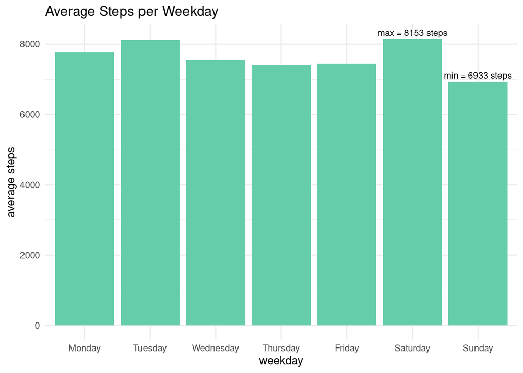

```r
daily_activity %>%
    group_by(weekday) %>%
    summarise(avg_steps = mean(totalsteps, na.rm = TRUE)) %>%
    ggplot(aes(x = weekday, y = avg_steps)) +
    geom_col(fill = "aquamarine3") +
  geom_text(aes(label = ifelse(avg_steps == max(avg_steps),
                               paste("max =", round(avg_steps), "steps"),
                               ifelse(avg_steps == min(avg_steps),
                                      paste("min =", round(avg_steps), "steps"), ""))),
            vjust = -0.5, color = "black", size = 3) +
    labs(title = "Average Steps per Weekday",
         x = "weekday",
         y = "average steps") +
    theme_minimal()
```

The chart displays the average number of steps taken on each day of the week. Saturday shows the highest average steps and Sunday the lowest.

Recommendations:

- Introduce a weekend challenge to encourage more steps on Sundays.
- Promote a daily steps goal of 10,000 steps, emphasizing increased activity on weekends.

### Relation of steps to calories consumpion

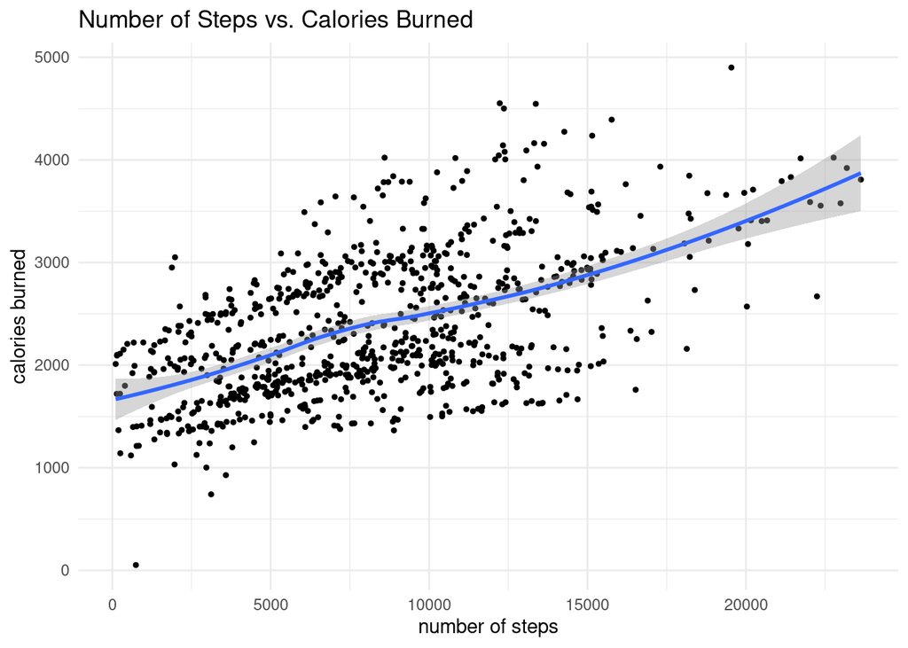

```r
daily_activity %>%
    filter(totalsteps > 100 & totalsteps < 25000) %>%
    ggplot(aes(x = totalsteps, y = calories)) +
    geom_point(color = "black", size = 0.9) +
    geom_smooth() +
    labs(
        title = "Number of Steps vs. Calories Burned",
        x = "number of steps",
        y = "calories burned"
    ) +
    theme_minimal()
```

There is a moderately strong positive correlation (approximately 0.6) between the number of steps taken and the calories burned.

Recommendations:

- Develop features in the app that provide real-time feedback on calories burned based on steps taken to motivate users.
- Use this data to personalize user goals for more effective health outcomes.

Note: outliers of daily step counts below 100 and above 25,000 have been filtered out for improved readability of the chart. However, they were included in the correlation calculations to provide a comprehensive analysis.

```r
round(cor(daily_activity$totalsteps, daily_activity$calories, use = "complete.obs"),1)
```

```
## [1] 0.6
```

### Logged activities check

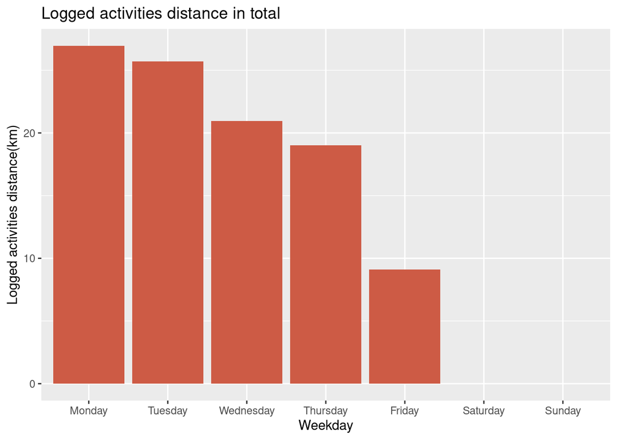

```r
ggplot(daily_activity, aes(x = weekday, y = loggedactivitiesdistance)) +
           geom_col(fill = "coral3") +
  labs(
    title = "Logged activities distance in total",
    x = "Weekday",
    y = "Logged activities distance(km)"
  )
```

The data reveals an absence of logged activities on Saturdays and Sundays. This could indicate a potential error in the data collection process.

Recommendations:

- Investigate and resolve the issue of missing activity logs on weekends.
- Encourage more consistent logging of activities through user reminders or incentives.

### Activity levels

Let’s start with creating a vector which will set intensities ordinarily:

```r
activity_levels <- c("lightlyactiveminutes", "fairlyactiveminutes", "veryactiveminutes")
```

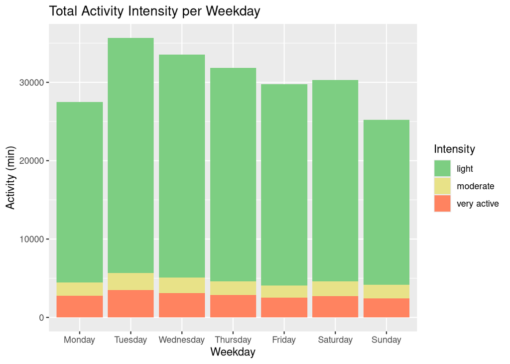

```r
daily_activity %>%
  select(date, weekday, lightlyactiveminutes, fairlyactiveminutes, veryactiveminutes) %>%
  pivot_longer(
    cols = c(lightlyactiveminutes, fairlyactiveminutes, veryactiveminutes),
    names_to = "activitytype",
    values_to = "minutes"
  ) %>%
  ggplot(aes(x = weekday, y = minutes, fill = factor(activitytype, levels = activity_levels))) +
  geom_col() +
  labs(
    title = "Total Activity Intensity per Weekday",
    x = "Weekday",
    y = "Activity (min)",
    fill = "Intensity"
  ) +
  scale_fill_manual(
    values = c("#7DCE82", "#E8E288", "#FF8360"),
    labels = c("light", "moderate", "very active")
  )
```

The data suggests that Tuesdays see the highest total minutes of activity, indicating a peak in overall activity levels.

Recommendations:

- Tailor promotional activities to increase moderate and very active minutes, especially on days with lower activity levels.
- Launch campaigns or challenges at the beginning of the week to boost overall weekly activity.

```r
daily_activity_summary <- daily_activity %>%
    select(lightlyactiveminutes, fairlyactiveminutes, veryactiveminutes) %>%
    pivot_longer(
        cols = c(lightlyactiveminutes, fairlyactiveminutes, veryactiveminutes),
        names_to = "activitytype",
        values_to = "minutes"
    ) %>%
    group_by(activitytype) %>%
    summarise(across(everything(), ~ round(mean(.), 1)))
```

### Activity piechart

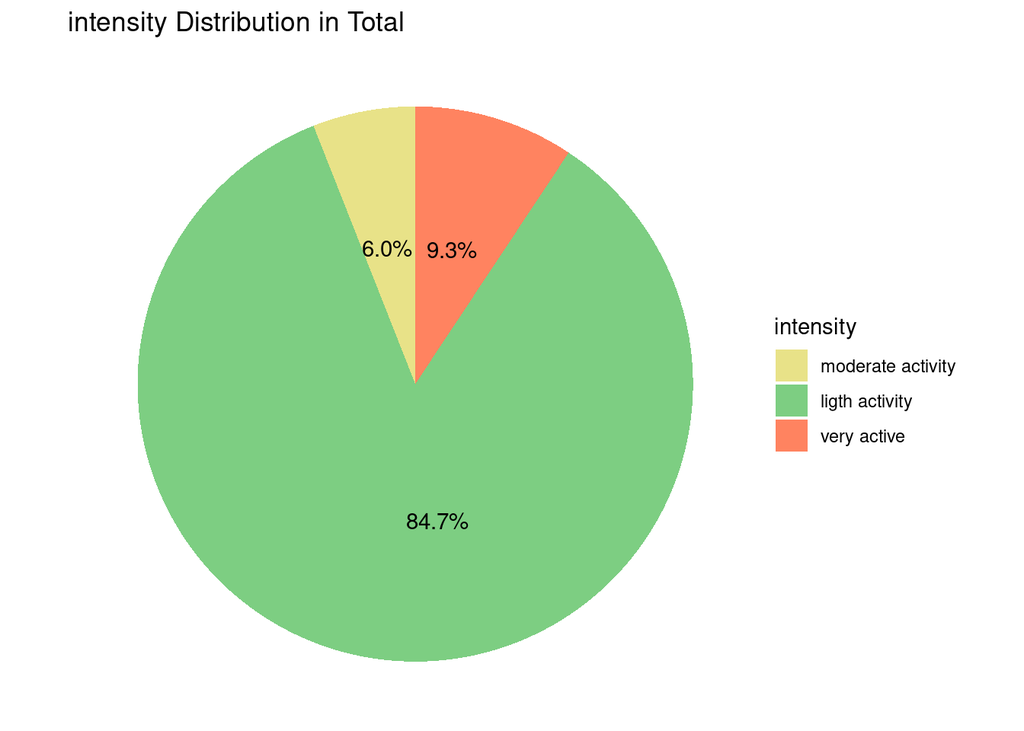

```r
# Custom color values and labels
color_values <- c("lightlyactiveminutes" = "#7DCE82", "fairlyactiveminutes" = "#E8E288", "veryactiveminutes" = "#FF8360")
label_values <- c("moderate activity", "ligth activity", "very active")

# adding total to the dataset
daily_activity_summary$total = sum(daily_activity_summary$minutes)

# Recalculate the percentage just in case and format it
daily_activity_summary_transformed <- daily_activity_summary %>%
  mutate(percentage = minutes / total) %>%
  mutate(labels = percent(percentage))

# Plotting a pie chart
ggplot(daily_activity_summary_transformed, aes(x = "", y = percentage, fill = activitytype)) +
  geom_bar(stat = "identity", width = 1) +
  coord_polar(theta = "y") +
  theme_void() +
  scale_fill_manual(values = color_values, labels = label_values) +
  labs(
    title = "intensity Distribution in Total",
    fill = "intensity") +
  geom_text(aes(label = scales::percent(percentage)), position = position_stack(vjust = 0.45), color = "black")
```

The chart shows a dominant 84.7% of activity classified as lightly active, with very active and fairly active minutes accounting for just 9.3% and 6% respectively. This distribution highlights a strong preference for lower-intensity activities among participants.

Recommendations:

- Enhance Light Activities: To keep users engaged, consider enhancing lightly active options with new, innovative activities that add variety while staying accessible.
- Promote Higher Intensity Engagement: Increase the visibility and appeal of higher-intensity activities through targeted promotions and incentives, aiming to capture interest from users seeking more challenging exercises.

### Activity heatmap

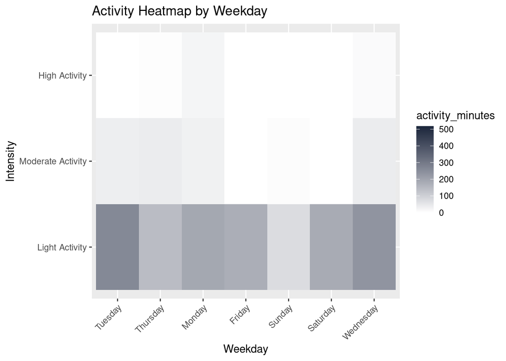

```r
daily_activity_sleep$weekday <- weekdays(daily_activity_sleep$date)

daily_activity_sleep %>%
    pivot_longer(
        cols = c(lightlyactiveminutes, fairlyactiveminutes, veryactiveminutes),
        names_to = "activity_type",
        values_to = "activity_minutes"
    ) %>%
    mutate(activity_type = factor(activity_type,
                                  levels = c("lightlyactiveminutes", "fairlyactiveminutes", "veryactiveminutes"),
                                  labels = c("Light Activity", "Moderate Activity", "High Activity"))) %>%
    ggplot(aes(x = fct_rev(fct_inorder(weekday)), y = activity_type, fill = activity_minutes)) +
    geom_tile() +
    scale_fill_gradientn(colors = c("white", "#1B263B"), values = scales::rescale(c(0, 10))) +
    labs(title = "Activity Heatmap by Weekday",
         x = "Weekday",
         y = "Intensity") +
    theme(axis.text.x = element_text(angle = 45, hjust = 1))
```

Alternative version of a previous chart.

Recommendations:

- Use the heatmap insights to plan targeted activity boosts, like midweek energizers.
- Encourage balanced activity throughout the week with varied intensity levels to keep users engaged.

### Weekday vs. weekend comparision

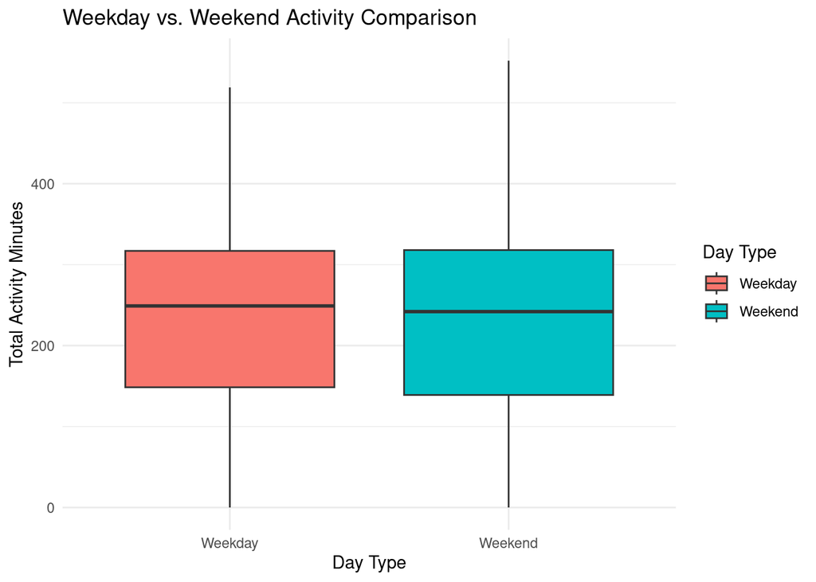

```r
daily_activity$totalactivitymins <- daily_activity$veryactiveminutes + daily_activity$fairlyactiveminutes + daily_activity$lightlyactiveminutes

daily_activity %>%
  mutate(day_type = ifelse(weekday %in% c("Saturday", "Sunday"), "Weekend", "Weekday")) %>%
  ggplot(aes(x = day_type, y = totalactivitymins, fill = day_type)) +
  geom_boxplot() +
  labs(title = "Weekday vs. Weekend Activity Comparison", x = "Day Type", y = "Total Activity Minutes", fill = "Day Type") +
  theme_minimal()
```

This boxplot illustrates the distribution of total activity minutes during weekdays versus weekends. The medians are similar, but the variability is greater on weekends, indicating that weekend activity levels are less consistent among individuals.

Recommendations:

### Average active time by weekday

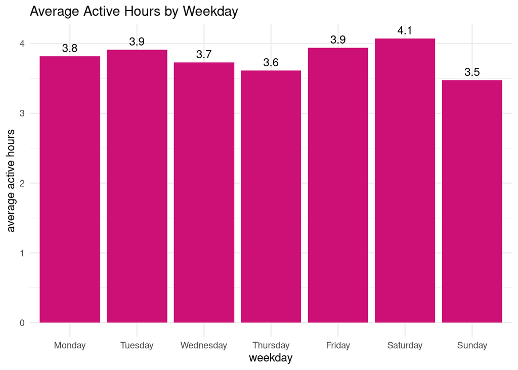

```r
daily_activity %>%
    na.omit() %>%
    group_by(weekday) %>%
    summarise(avg_active_hours = mean(totalactivitymins) / 60) %>%
    ggplot(aes(x = weekday, y = avg_active_hours, fill = "deeppink3")) +
    geom_col() +
    geom_text(aes(label = sprintf("%.1f", avg_active_hours)), vjust = -0.5) +
    scale_fill_manual(values = "deeppink3", guide = "none") +
    labs(title = "Average Active Hours by Weekday",
         x = "weekday",
         y = "average active hours") +
    theme_minimal()
```

## Sleep

This series of charts, including bar charts and distribution graphs, explores patterns in sleep duration and quality across the week.

### Hours of sleep per weekday

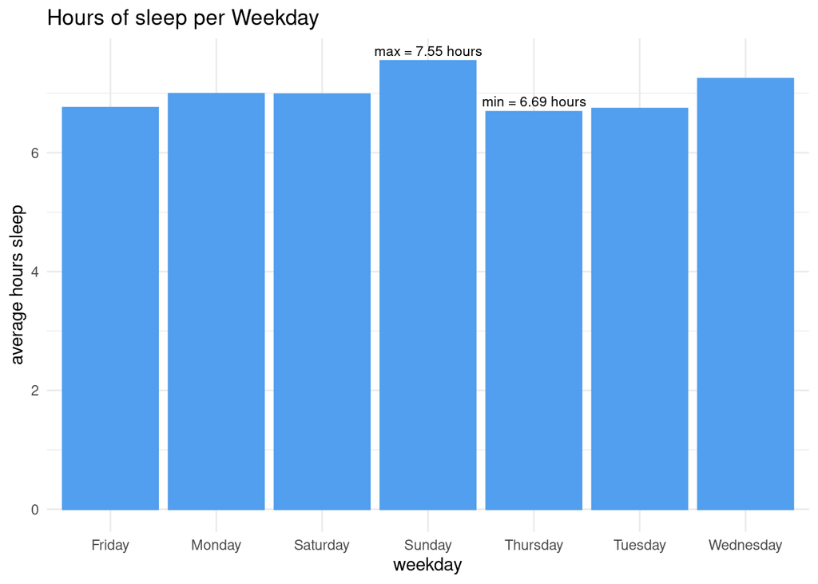

```r
daily_activity_sleep %>%
    group_by(weekday) %>%
    summarise(avg_sleep = mean(totalminutesasleep, na.rm = TRUE)/60) %>%
    ggplot(aes(x = weekday, y = avg_sleep)) +
    geom_col(fill = "#529EEF", color = "#529EEA") +
    geom_text(aes(label = ifelse(avg_sleep == max(avg_sleep),
                                 paste("max =", round(avg_sleep,2), "hours"),
                                 ifelse(avg_sleep == min(avg_sleep),
                                        paste("min =", round(avg_sleep,2), "hours"), ""))),
              vjust = -0.5, color = "black", size = 3) +
    labs(title = "Hours of sleep per Weekday",
         x = "weekday",
         y = "average hours sleep") +
    theme_minimal()
```

Recommendations:

- Aim to even out the rest periods by providing tips on maintaining a stable sleep schedule throughout the week.
- Offer advice on relaxation techniques that could help increase restful sleep on the shorter nights.

### Sleep distribution

```r
daily_activity_sleep <- daily_activity_sleep %>%
  filter(!is.na(totalminutesasleep)) %>%
  mutate(hours_asleep_cluster = cut(totalminutesasleep / 60, breaks = seq(0, 14, by = 1), labels = c("0-1", "1-2", "2-3", "3-4", "4-5", "5-6", "6-7", "7-8", "8-9", "9-10", "10-11", "11-12", "12-13", "13-14"), include.lowest = TRUE))
```

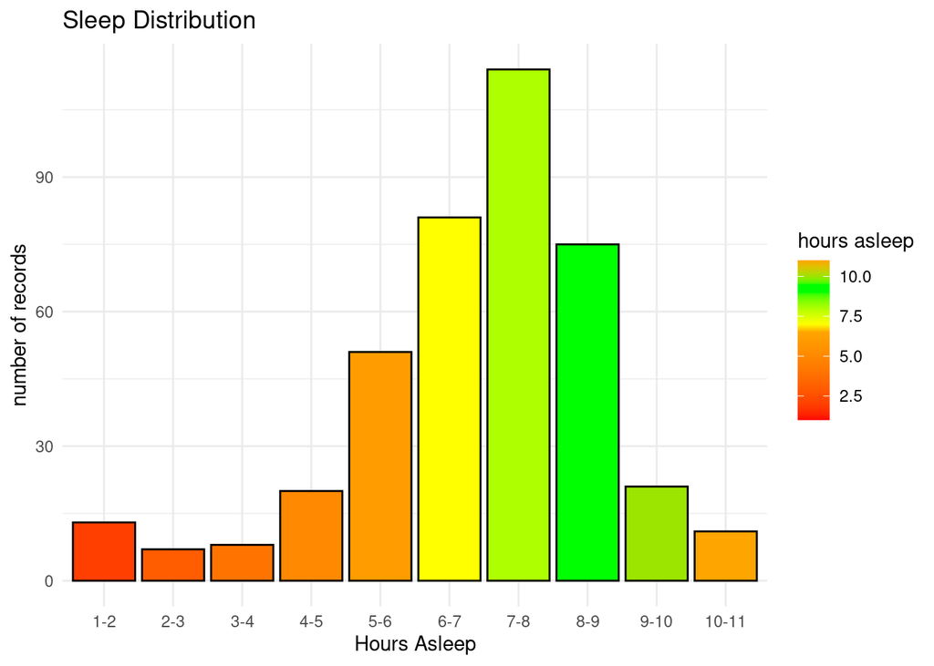

```r
daily_activity_sleep %>%
    filter(!is.na(totalminutesasleep)) %>%
    filter(totalminutesasleep > 60 & totalminutesasleep < 660) %>%
    mutate(hours_asleep_cluster = cut(totalminutesasleep / 60,
                                      breaks = seq(0, 11, by = 1),
                                      labels = c("0-1", "1-2", "2-3", "3-4", "4-5", "5-6", "6-7", "7-8", "8-9", "9-10","10-11"),
                                      include.lowest = TRUE)) %>%
    ggplot(aes(x = hours_asleep_cluster, fill = as.numeric(hours_asleep_cluster))) +
    geom_bar(color = "black") +
    scale_fill_gradientn(colors = c("red", "orange", "yellow", "green", "green", "orange"),
                         values = c(0, 0.55, 0.6, 0.8, 0.85, 1),
                         limits = c(1, 11)) +
    labs(title = "Sleep Distribution",
         x = "Hours Asleep",
         y = "number of records",
         fill = "hours asleep") +
    theme_minimal()
```

The analysis highlights that a notable portion of sleep records (182 in total) falls within or below the 6-7 hour range, indicating insufficient sleep duration.

Recommendations:

- Consider strategies that reinforce the health benefits of 7-8 hours of sleep, reinforcing this as the standard.
- Investigate the causes of both very short and very long sleep durations to offer targeted guidance for those outliers.

```r
daily_activity_sleep %>%
  filter(!is.na(totalminutesasleep)) %>%
  mutate(hours_asleep_cluster = cut(totalminutesasleep / 60, breaks = seq(0, 10, by = 1), labels = c("0-1", "1-2", "2-3", "3-4", "4-5", "5-6", "6-7", "7-8", "8-9", "9-10"), include.lowest = TRUE)) %>%
  group_by(hours_asleep_cluster) %>%
  summarise(num_records = n()) %>%
  filter(as.character(hours_asleep_cluster) <= "6-7") %>%
  summarise(total_records_6_to_7_hours_or_lower = sum(num_records))
```

```
## # A tibble: 1 × 1
##   total_records_6_to_7_hours_or_lower
##                                 <int>
## 1                                 182
```

### Time in Bed Without Sleep

```r
daily_activity_sleep$bedtimegap <- daily_activity_sleep$totaltimeinbed - daily_activity_sleep$totalminutesasleep
```

```r
avg_bedtime_gap <- daily_activity_sleep %>%
    na.omit() %>%
    group_by(weekday) %>%
    summarise(avgbedtimegap = mean(bedtimegap)) %>%
  mutate(avgbedtimegap = round(avgbedtimegap,1))
```

Creating a factor

```r
avg_bedtime_gap$weekday <- factor(avg_bedtime_gap$weekday, levels = c("Monday", "Tuesday", "Wednesday", "Thursday", "Friday", "Saturday", "Sunday"), ordered = TRUE)
```

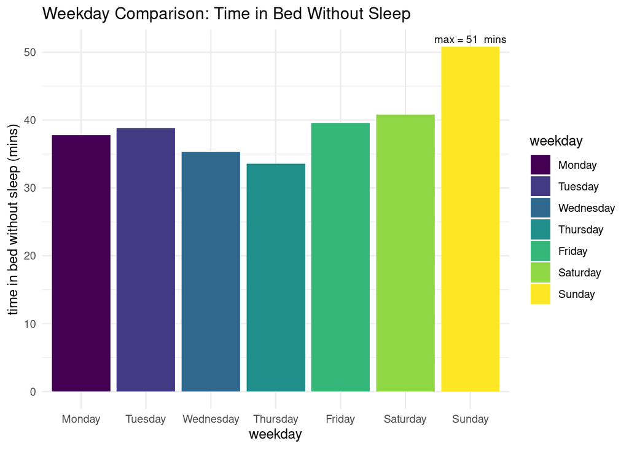

```r
ggplot(avg_bedtime_gap, aes(x = weekday, y = avgbedtimegap, fill = weekday)) +
    geom_col() +
    geom_text(aes(label = ifelse(avgbedtimegap == max(avgbedtimegap),
                                 paste("max =",round(avgbedtimegap), " mins"), "")),
              vjust = -0.5, color = "black", size = 3) +
    labs(
        title = "Weekday Comparison: Time in Bed Without Sleep",
        x = "weekday",
        y = "time in bed without sleep (mins)"
    ) +
    theme_minimal()
```

The analysis reveals that Sunday has the highest average time in bed without sleep, reaching a maximum of 51 minutes, suggesting an opportunity to promote quality time in bed through initiatives such as reducing blue screen exposure before bedtime and encouraging activities like reading or relaxation.

## Correlation matrix

```r
daily_activity_sleep$totalactivitymins = daily_activity_sleep$veryactiveminutes + daily_activity_sleep$fairlyactiveminutes + daily_activity_sleep$lightlyactiveminutes

correlation_matrix <- daily_activity_sleep %>%
  select(totalsteps, totaldistance, totalminutesasleep, totalactivitymins, calories, sedentaryminutes) %>%
  cor()
```

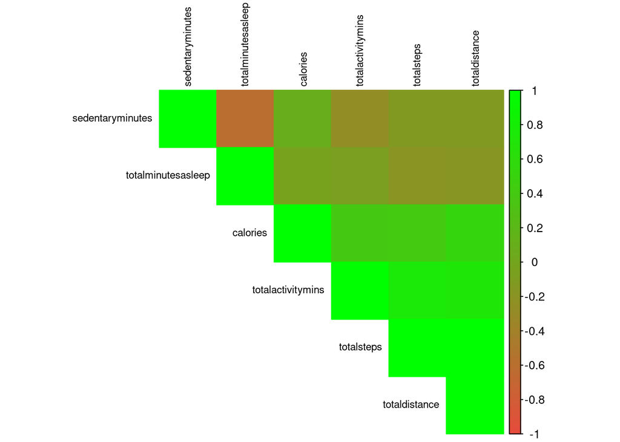

```r
color_palette <- colorRampPalette(c("#e74c3c", "green"))(100)

corrplot(correlation_matrix,
         method = "color",
         type = "upper",
         order = "hclust",
         tl.cex = 0.7,
         tl.col = "black",
         col = color_palette)
```

Recommendations:

- Develop features that leverage correlations to provide personalized health insights and recommendations.
- Use insights from sedentary minutes and sleep data to encourage less sedentary behavior and more restful nights.

## Average sedentery time

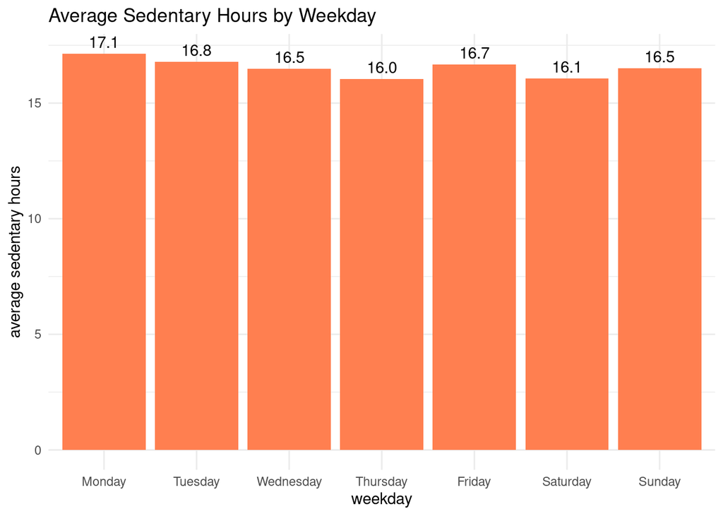

```r
daily_activity %>%
  na.omit() %>%
  group_by(weekday) %>%
  summarise(avg_sed = mean(sedentaryminutes) / 60) %>%
  ggplot(aes(x = weekday, y = avg_sed, fill = "coral")) +
  geom_col() +
  geom_text(aes(label = sprintf("%.1f", avg_sed)), vjust = -0.5) +  # Add labels with average values
  scale_fill_manual(values = "coral", guide = FALSE) +  # Remove the legend
  labs(title = "Average Sedentary Hours by Weekday",
       x = "weekday",
       y = "average sedentary hours") +
  theme_minimal()
```

```r
daily_activity %>%
  na.omit() %>%
  summarise(average_sedentary_hours = mean(sedentaryminutes) / 60) %>%
  mutate(average_sedentary_hours = round(average_sedentary_hours,2))
```

```
## # A tibble: 1 × 1
##   average_sedentary_hours
##                     <dbl>
## 1                    16.5
```

Based on the data, the average amount of sedentary time during the week appears to be notably high, at 16.5 hours.

### Hourly intensities throughout the day

```r
hourly_intensities <- hourly_intensities %>%
  separate(date_time, into = c("date", "time"), sep= " ")
```

### Average total intensity vs. time

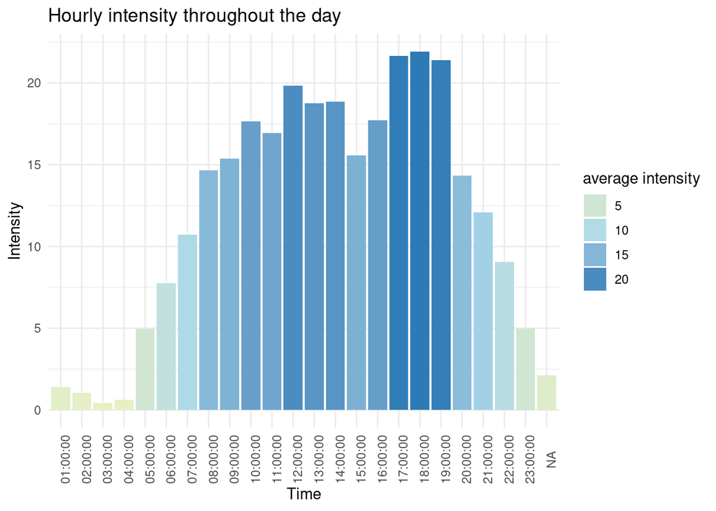

```r
hourly_intensities %>%
  group_by(time) %>%
  summarize(average_intensity = mean(totalintensity)) %>%
  ggplot() +
  geom_col(mapping = aes(x = time, y = average_intensity, fill = average_intensity)) +
  labs(
    title = "Hourly intensity throughout the day",
    x = "Time",
    y = "Intensity",
    fill = "average intensity") +
  scale_fill_gradientn(
    colours = c("#E7F0C3", "#ABD9E9", "#2C7BB6"),  # Modern color palette
    values = c(0, 0.5, 1),  # Custom scale points
    guide = "legend"  # Show legend
  ) +
  theme_minimal() +
  theme(axis.text.x = element_text(angle = 90))
```

The data shows a notable rise in activity intensity during the midday hours, peaking between 12 PM and 2 PM and then 5 PM to 7 PM, which then tapers off as the evening progresses.

Recommendations:

- Explore opportunities for morning and evening activity initiatives to extend the peak intensity beyond the afternoon.
- Promote relaxation and recovery strategies post-peak to facilitate a healthy balance between activity and rest.

### Hourly steps

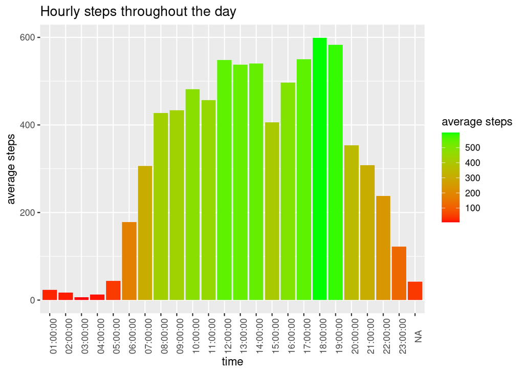

```r
hourly_steps <- hourly_steps %>%
  separate(date_time, into = c("date","time"), sep = " ") %>%
  mutate(date = ymd(date))

hourly_steps %>%
  group_by(time) %>%
  summarize(average_steps = mean(steptotal)) %>%
  ggplot() +
  geom_col(mapping = aes(x=time, y = average_steps, fill = average_steps)) +
  labs(
    title = "Hourly steps throughout the day",
    x="time",
    y="average steps",
    fill = "average steps") +
  scale_fill_gradient(low = "red", high = "green")+
  theme(axis.text.x = element_text(angle = 90))
```

### Hourly calories

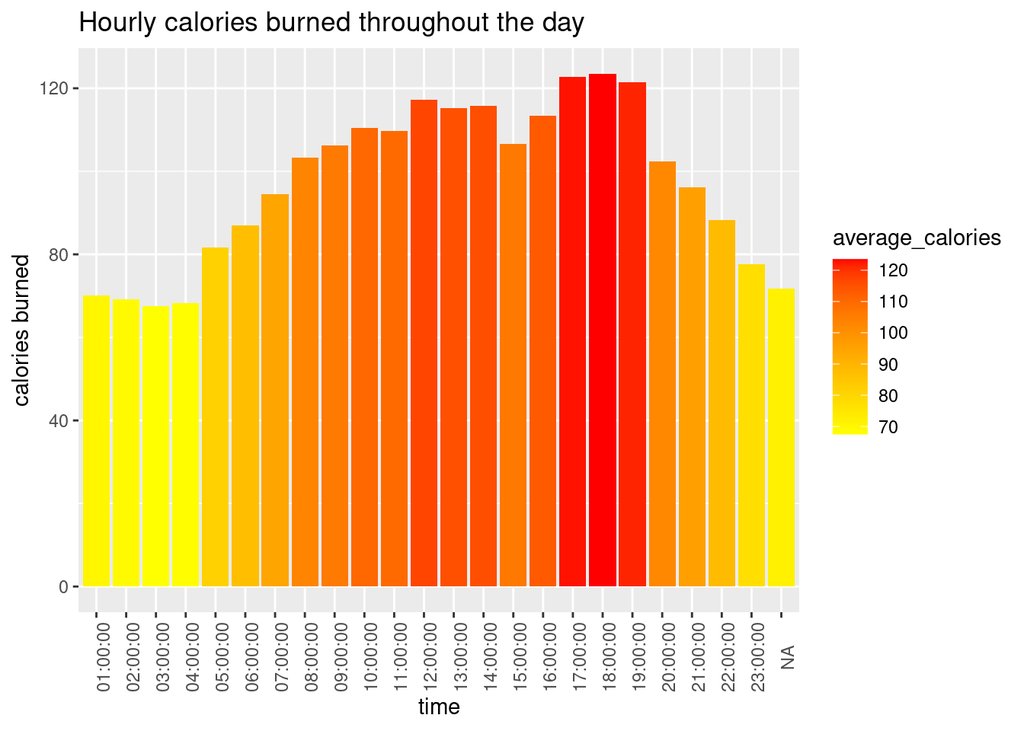

```r
hourly_calories <- hourly_calories %>%
    separate(date_time, into = c("date", "time"), sep = " ")

hourly_calories %>%
  group_by(time) %>%
  summarize(average_calories = mean(calories)) %>%
  ggplot() +
  geom_col(mapping = aes(x=time, y = average_calories, fill = average_calories)) +
  labs(title = "Hourly calories burned throughout the day", x="time", y="calories burned") +
  scale_fill_gradient(low = "yellow", high = "red")+
  theme(axis.text.x = element_text(angle = 90))
```

Calorie burn data spikes from late morning to early evening, displaying a robust correlation with the previously noted trends in activity intensity and step count.

Recommendation:

- Suggest engaging in light, calorie-burning activities for the early morning hours to kick-start the day’s metabolism.

## User types

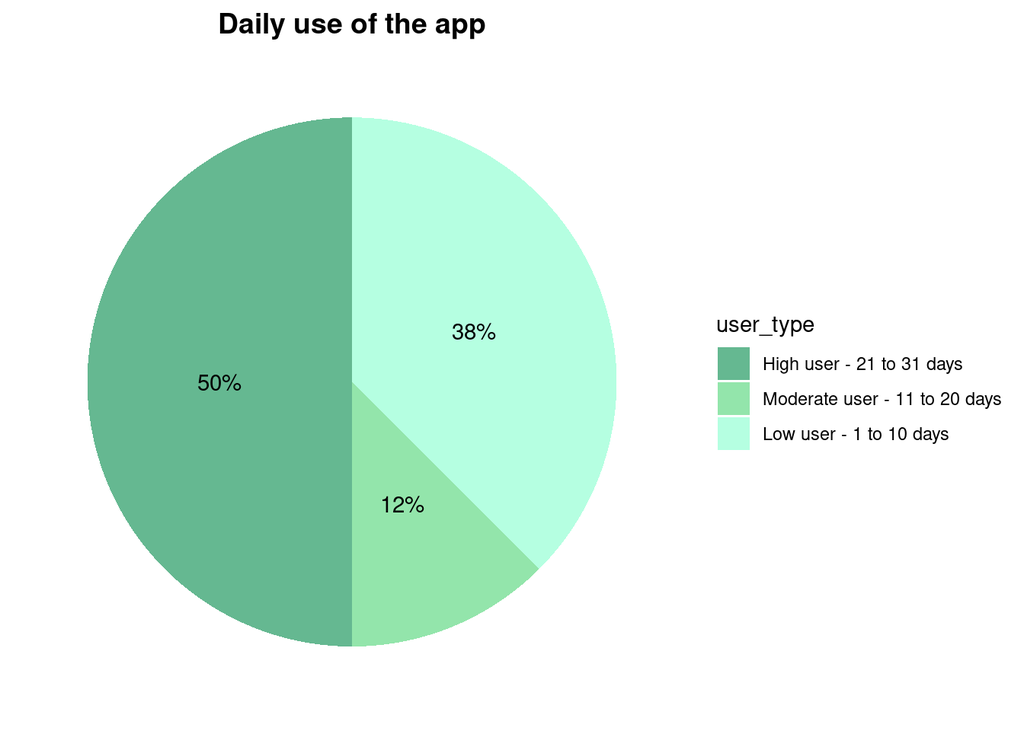

```r
daily_use <- daily_activity_sleep %>%
  group_by(id) %>%
  summarize(days_used=sum(n())) %>%
  mutate(user_type= case_when(
    days_used >= 1 & days_used <= 10 ~ "low user",
    days_used >= 11 & days_used <= 20 ~ "moderate user",
    days_used >= 21 & days_used <= 31 ~ "heavy user",
  ))

daily_use_percent <- daily_use %>%
  group_by(user_type) %>%
  summarise(total = n()) %>%
  mutate(totals = sum(total)) %>%
  group_by(user_type) %>%
  summarise(total_percent = total / totals) %>%
  mutate(labels = scales::percent(total_percent))

daily_use_percent$user_type <- factor(daily_use_percent$user_type, levels = c("heavy user", "moderate user", "low user"))

daily_use_percent %>%
  ggplot(aes(x = "",y = total_percent, fill = user_type)) +
  geom_bar(stat = "identity", width = 1)+
  coord_polar("y", start=0)+
  theme_minimal()+
  theme(axis.title.x= element_blank(),
        axis.title.y = element_blank(),
        panel.border = element_blank(),
        panel.grid = element_blank(),
        axis.ticks = element_blank(),
        axis.text.x = element_blank(),
        plot.title = element_text(hjust = 0.5, size=14, face = "bold")) +
  geom_text(aes(label = labels),
            position = position_stack(vjust = 0.5))+
  scale_fill_manual(values = c( "#65B891","#93E5AB","#B5FFE1"),
                    labels = c("High user - 21 to 31 days",
                               "Moderate user - 11 to 20 days",
                               "Low user - 1 to 10 days"))+
  labs(title="Daily use of the app")
```

The pie chart vividly segments smart device usage into three categories, showing half of the users as high users, which suggests a strong engagement with the device.

Recommendations:

- Design a rewards program to maintan loyalty of high users.
- Develop targeted programs to convert moderate and low users into more consistent users.

## Recommendations for Bellabeat Smart Device Trends Analysis

### Product Development Recommendations

- **Enhance App Features**: Integrate real-time feedback mechanisms in the app that monitor and report on activity levels and sleep quality dynamically.
- **Consistency Features**: Develop functionalities that encourage users to maintain consistent activity and sleep routines. For example you can introduce workout or well-being programs.

### Marketing Strategy Recommendations

- **Weekend Engagement**: Launch targeted promotions to increase user activity during the weekends (especially Sunday), such as virtual challenges or community competitions.
- **Personalized Marketing**: Leverage data insights to tailor marketing messages that resonate with individual user habits and preferences.

### Data Handling and Future Analysis Recommendations

- **Advanced Analytics**: Apply machine learning algorithms to predict user behavior patterns and potential churn, improving retention strategies.
- **Expand Dataset**: Acquire more comprehensive datasets that include newer data and a wider demographic to enhance analysis accuracy.
  - Motivate users to log their weight.
  - Insights into users’ lifestyles, preferences, motivations, and health goals could provide more nuanced understanding of how they interact with the smart devices and what drives their engagement.
  - More detailed demographic data such as age, gender, income level, and geographical location could help tailor products and marketing strategies more effectively to different user segments.

### User Engagement Recommendations

- **User Conversion Programs**: Implement a tiered rewards program to motivate moderate and low users to increase their usage frequency.
- **Promote Intense Activities**: Use targeted campaigns to make high-intensity activities appealing, offering incentives for participation.

### Additional research

```r
activity_sleep_long <- daily_activity_sleep %>%
  na.omit() %>%
  select(weekday, totaltimeinbed, totalminutesasleep, calories, veryactiveminutes, fairlyactiveminutes, lightlyactiveminutes, sedentaryminutes) %>%
  pivot_longer(
    cols = c(veryactiveminutes, fairlyactiveminutes, lightlyactiveminutes, sedentaryminutes),
    names_to = "intensity",
    values_to = "minutes"
  )
```